# Unveiling 三国演义 Text Analysis Using R

June 24, 2024

## Romance of the Three Kingdoms 三国演义

- The book Romance of the Three Kingdoms is a text about the Chinese history that depicts the fights of powerful figures which leads to multiple dynasties rising and falling.
- Some characters in the story that you may recognize are: Liu Bei, Zhang Fei, Guan Yu, Cao Cao, and Zhuge Liang.

## Goals

- Analyze the frequency and usage of words
- Analyze the sentiment- Segmentation of Chinese words
- Word frequency analysis: most common words in the book
- Sentiment analysis

## Method

- Collect text data
- Preprocess the text data (cleaning, tokenization).
- Perform word frequency analysis
- Perform sentiment analysis

## Text data: Raw

- This is the UNTIDY version of the text

```
##  [1] "《三国演义》罗贯中"
##  [2] ""
##  [3] "第一回 宴桃园豪杰三结义 斩黄巾英雄首立功"
##  [4] ""
##  [5] "    \t\t"
##  [6] ""
##  [7] "    滚滚长江东逝水，浪花淘尽英雄。是非成败转头空。"
##  [8] ""
##  [9] "    青山依旧在，几度夕阳红。白发渔樵江渚上，惯"
## [10] ""
## [11] "    看秋月春风。一壶浊酒喜相逢。古今多少事，都付"
## [12] ""
## [13] "    笑谈中。"
## [14] ""
## [15] "    ——调寄《临江仙》"
```

## Text data: Dataframe

| line | text |
| --- | --- |
| 1 | 《三国演义》罗贯中 |
| 2 |  |
| 3 | 第一回 宴桃园豪杰三结义 斩黄巾英雄首立功 |
| 4 |  |
| 5 |  |
| 6 |  |
| 7 | 滚滚长江东逝水，浪花淘尽英雄。是非成败转头空。 |
| 8 |  |
| 9 | 青山依旧在，几度夕阳红。白发渔樵江渚上，惯 |
| 10 |  |

## Text data: Tidy

- This is the TIDY version of the text

```
## Rows: 392,412
## Columns: 2
## $ line <int> 1, 1, 1, 3, 3, 3, 3, 3, 3, 3, 3, 3, 3, 3, 3, 3, 7, 7, 7, 7, 7, 7,…
## $ word <chr> "三国", "演义", "罗贯中", "第一", "回", "宴", "桃园", "豪杰", "三…
```

| line | word |
| --- | --- |
| 1 | 三国 |
| 1 | 演义 |
| 1 | 罗贯中 |
| 3 | 第一 |
| 3 | 回 |
| 3 | 宴 |
| 3 | 桃园 |
| 3 | 豪杰 |
| 3 | 三 |
| 3 | 结 |

## Chinese Word Segmentation

- Unlike English, where each word token is delimited by white spaces, Chinese word tokens are much less straightforward. A word, however, is an important semantic unit in many linguistic analysis.
- Chinese word `cutter` `jiebaR`

| line | word |
| --- | --- |
| 1 | 三国演义 |
| 1 | 罗贯中 |
| 3 | 第一回 |
| 3 | 宴 |
| 3 | 桃园 |
| 3 | 豪杰 |
| 3 | 三 |
| 3 | 结义 |
| 3 | 斩 |
| 3 | 黄巾 |

## Word frequencies

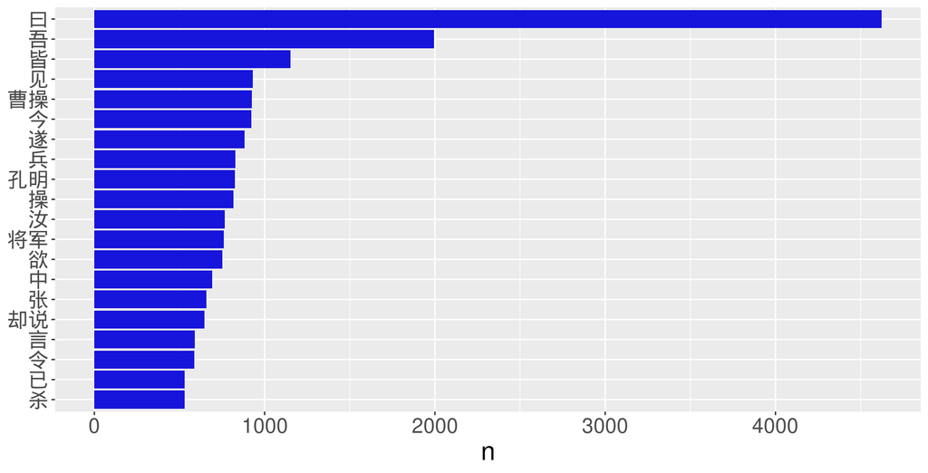

## Wordcloud

[interactive chart not shown]

## Sentiment analysis

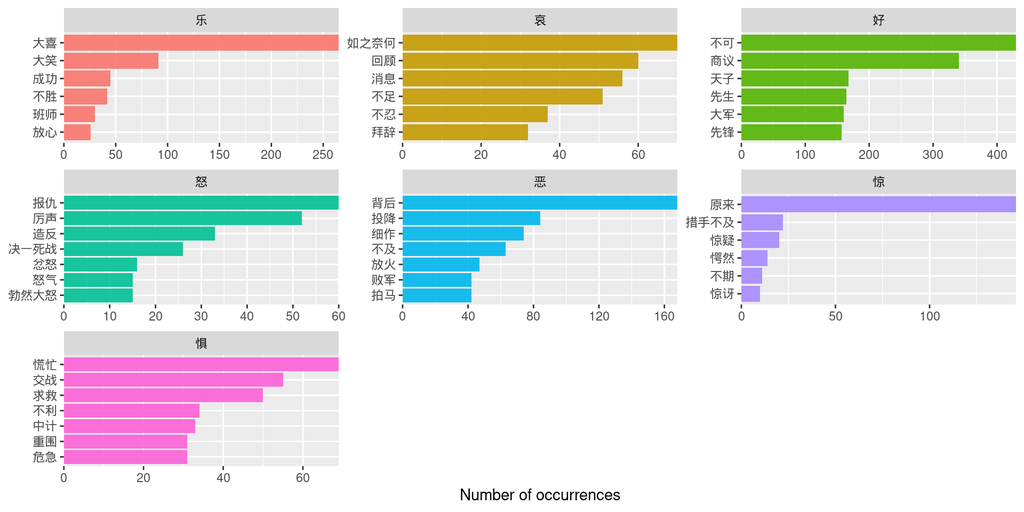

## Track sentiment in book

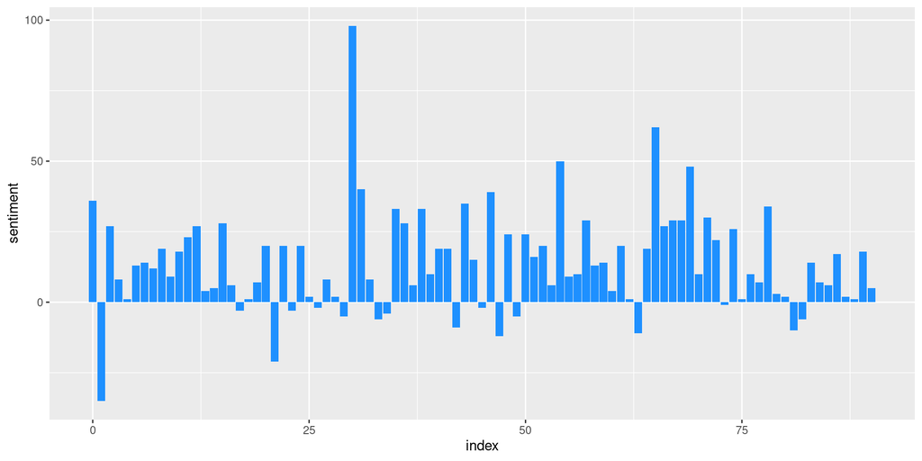

## Summary

- Segmentation of Chinese words
- Word frequency analysis: most common words in the book
- Sentiment analysis